# 2864assignment1

Yufei xia

2019/1/20

## Question1

```r
#search the package
search()
```

```
## [1] ".GlobalEnv"        "package:stats"     "package:graphics"
## [4] "package:grDevices" "package:utils"     "package:datasets"
## [7] "package:methods"   "Autoloads"         "package:base"
```

```r
#find the package and normal distribution use object function
objects("package:stats",pattern = "norm")
```

```
## [1] "dlnorm" "dnorm"  "plnorm" "pnorm"  "qlnorm" "qnorm"  "qqnorm" "rlnorm"
## [9] "rnorm"
```

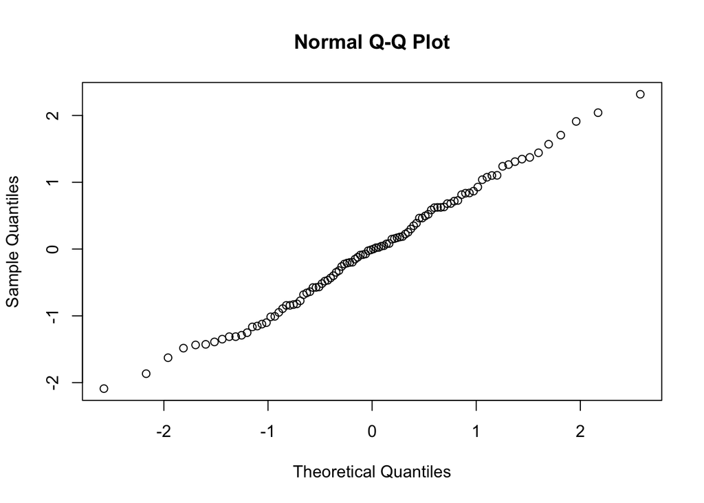

```r
?rnorm
?qqnorm
#generate 100 random numbers according to normal distribution with mean = 0 stardard deviation = 1
x = rnorm(100)
#qqnorm is a generic function the default method of which produces a normal QQ plot of the values in y,and compare the theoritical quantile with pratical quantile.
qqnorm(x)
```

the rnorm(100) generate 100 random numbers according to normal distribution with mean = 0 stardard deviation = 1. the qqnorm(x) is a generic function the default method of which produces a normal QQ plot of the values in x,and compare the theoritical quantile with pratical quantile.

## Question2

```r
#sum of 100 number using sum function

x = sample(1:100)
sum1 = sum(x)
#sum of 100 numbers using for loop
#set 0 initially
sum2 = 0
for (i in 1:100){
  sum2 = sum2 + x[i]
}
print("the first sum is")
```

```
## [1] "the first sum is"
```

```r
sum1
```

```
## [1] 5050
```

```r
print("the second sum is")
```

```
## [1] "the second sum is"
```

```r
sum2
```

```
## [1] 5050
```

the for loop and sum function get the same result.

```r
#genelize 100 number form 1 to the 100
x=sample(1:100)
#get the smallest using the min function
min1 = min(x)
#get the smallest using the for loop
min2 = x[1]
for(i in 2:100){
  if(min2>x[i]){
    min2=x[i]
  }
}
print("the first min is")
```

```
## [1] "the first min is"
```

```r
print(min1)
```

```
## [1] 1
```

```r
print("the second min is")
```

```
## [1] "the second min is"
```

```r
print(min2)
```

```
## [1] 1
```

the for loop and the min function get the same result.

## question3

```r
#intilize the sum and sum1 being the 4 elements vector.
n = c(10,20,30,40)
sum =c(0,0,0,0)
sum1 =c(0,0,0,0)
#using the for loop to calculate
for(i in 1:4){
  for(j in 0:n[i]){
    sum[i]= sum[i]+1.05^j
  }
}
sum
```

```
## [1]  14.20679  35.71925  70.76079 127.83976
```

```r
#using the formula to calculate the sum of
for(i in 1:4){
  sum1[i]=(1-1.05^(n[i]+1))/(1-1.05)
}
sum1
```

```
## [1]  14.20679  35.71925  70.76079 127.83976
```

this show that the for loop and equation get the same results.

## question4

```r
#set up each individual columns
c1 <- c(1:8);
c2 <- c(rep(1,4),rep(2,4))
c3 <- c(rep(1,2),rep(2,2),rep(1,2),rep(2,2))
c4 <- c(rep(1:2,4))
 #using cbind to combine all the columns together
cbind(c1,c2,c3,c4)
```

```
##      c1 c2 c3 c4
## [1,]  1  1  1  1
## [2,]  2  1  1  2
## [3,]  3  1  2  1
## [4,]  4  1  2  2
## [5,]  5  2  1  1
## [6,]  6  2  1  2
## [7,]  7  2  2  1
## [8,]  8  2  2  2
```

## question5

```r
#find third row
Formaldehyde[3,]
```

```
##   carb optden
## 3  0.5  0.446
```

```r
#5(b)
#find carb column
Formaldehyde$carb
```

```
## [1] 0.1 0.3 0.5 0.6 0.7 0.9
```

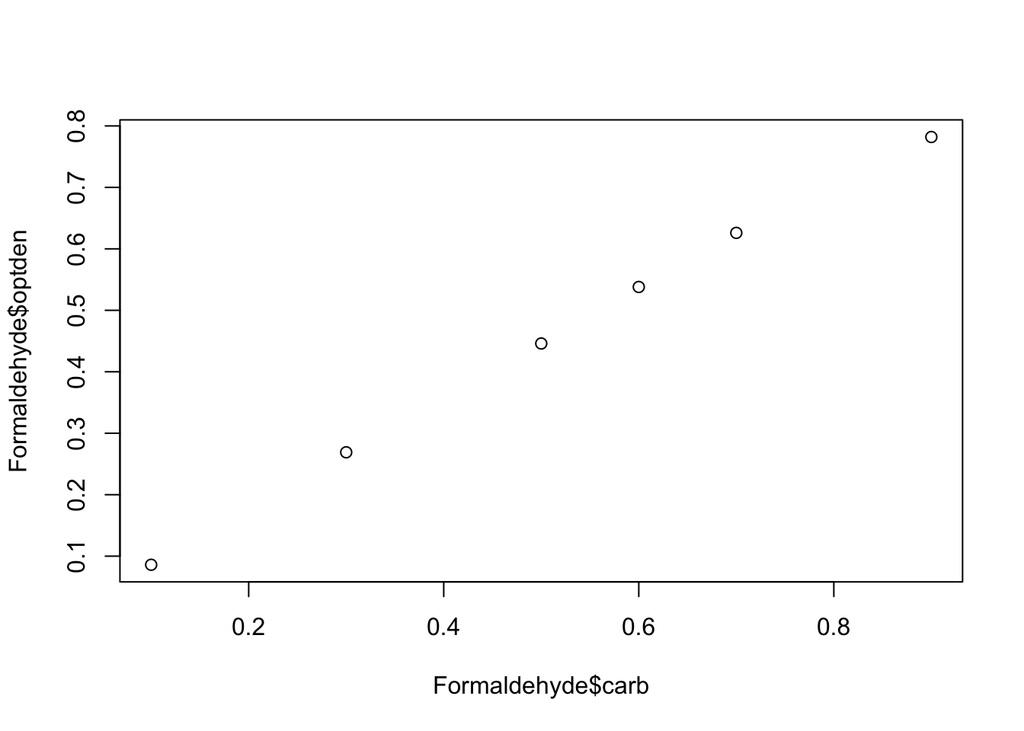

```r
#5(c)
#ploy with x-axis is carb, y-axis is optden
plot(Formaldehyde$carb,Formaldehyde$optden)
```

from the plot we can see that there is an obvious relation between carb and optden in the formaldehyde graph.

## question6

```r
#Determine the number of rows and columns for this data frame.
library(MASS)
nrow(Pima.tr)
```

```
## [1] 200
```

```r
ncol(Pima.tr)
```

```
## [1] 8
```

```r
print("the median of different columns is")
```

```
## [1] "the median of different columns is"
```

```r
#set different columns as vectors
x1=Pima.tr[,1]
x2=Pima.tr[,2]
x3=Pima.tr[,3]
x4=Pima.tr[,4]
x5=Pima.tr[,5]
x6=Pima.tr[,6]
x7=Pima.tr[,7]
#calculate median of each column
median(x1)
```

```
## [1] 2
```

```r
median(x2)
```

```
## [1] 120.5
```

```r
median(x3)
```

```
## [1] 70
```

```r
median(x4)
```

```
## [1] 29
```

```r
median(x5)
```

```
## [1] 32.8
```

```r
median(x6)
```

```
## [1] 0.3725
```

```r
median(x7)
```

```
## [1] 28
```

```r
print("the bmi for different type is as followed")
```

```
## [1] "the bmi for different type is as followed"
```

```r
mean(Pima.tr$bmi[Pima.tr$type =="Yes"])
```

```
## [1] 34.70882
```

```r
mean(Pima.tr$bmi[Pima.tr$type =="No"])
```

```
## [1] 31.07424
```

## question7

```r
Cars93
```

[output not shown]

[output cut: 455 more lines]

```r
#find the number of columns
ncol(Cars93)
```

```
## [1] 27
```

```r
#find the columns names
colnames(Cars93)
```

```
##  [1] "Manufacturer"       "Model"              "Type"
##  [4] "Min.Price"          "Price"              "Max.Price"
##  [7] "MPG.city"           "MPG.highway"        "AirBags"
## [10] "DriveTrain"         "Cylinders"          "EngineSize"
## [13] "Horsepower"         "RPM"                "Rev.per.mile"
## [16] "Man.trans.avail"    "Fuel.tank.capacity" "Passengers"
## [19] "Length"             "Wheelbase"          "Width"
## [22] "Turn.circle"        "Rear.seat.room"     "Luggage.room"
## [25] "Weight"             "Origin"             "Make"
```

```r
#find the weight as vector of name "weight"
weight=Cars93$Weight
q=cut(weight,c(0,2500,3500,Inf))
#seperate the different stardard.
cars.size=factor(q,labels=c("small","medium","large"))
#add new column
cbind(Cars93,cars.size)
```

[output not shown]

[output cut: 455 more lines]

```r
#calculate each mean with small, medium and large sizees of cars
mean(Cars93$MPG.city[cars.size =="small"])
```

```
## [1] 30.45
```

```r
mean(Cars93$MPG.city[cars.size =="medium"])
```

```
## [1] 21.58696
```

```r
mean(Cars93$MPG.city[cars.size =="large"])
```

```
## [1] 17.7037
```

c)the result show that the larger the carsize is, the less MPG it is.